# Data550 Final Dataset

Mia Yang

# Final Project: Modeling Medical Insurance Charges Using Demographic and Lifestyle Factors

# Check the location of data

```r
here::here ("Data550_Final_Project.Rmd")
```

```
## [1] "/Users/ymy/Desktop/Data550_Final/Data550_Final_Project.Rmd"
```

# 1. Introduction:

## 1.1 Dataset

My dataset was chosen from *kaggle* and it is a *[Medical Insurance Cost dataset](https://www.kaggle.com/datasets/mosapabdelghany/medical-insurance-cost-dataset)*.(Click on italic text to see the website and the data).

```r
absolute_path_data_final <- here::here("raw_data", "insurance.csv")

final_data <- read.csv(absolute_path_data_final, header = TRUE)

head(final_data)
```

```
##   age    sex    bmi children smoker    region   charges
## 1  19 female 27.900        0    yes southwest 16884.924
## 2  18   male 33.770        1     no southeast  1725.552
## 3  28   male 33.000        3     no southeast  4449.462
## 4  33   male 22.705        0     no northwest 21984.471
## 5  32   male 28.880        0     no northwest  3866.855
## 6  31 female 25.740        0     no southeast  3756.622
```

## 1.2 Objective of this Project:

Health insurance costs are influenced by a range of demographic and lifestyle characteristics, such as age, sex, body mass index (BMI), smoking status, and geographic region. Understanding how these factors contribute to medical expenses can provide valuable insights for health policy, insurance providers, and individuals seeking affordable care.

## 1.3 Description of the Data:

The dataset used in this analysis, the Medical Insurance Cost Dataset (sourced from Kaggle), contains records for 1,338 individuals. Each record includes demographic variables (age, sex, region), lifestyle indicators (BMI, smoking status, number of children), and the corresponding insurance charges billed to the individual. This dataset is widely used for teaching statistical modeling and health economics because it offers a structured, real-world–inspired look at cost variation.

# 2. Descriptive Analysis:

## 2.1 Table 1:

Characteristics of the 1338 data points from the insurance database are displayed in the table below.

| **Characteristic** | **By Insurance Charges (High vs Low)** **Overall** N = 1,338<sup>1</sup> | **By Insurance Charges (High vs Low)** **High** N = 669<sup>1</sup> | **By Insurance Charges (High vs Low)** **Low** N = 669<sup>1</sup> | **p-value**<sup>2</sup> |  |
| --- | --- | --- | --- | --- | --- |
| age | 39 (27, 51) | 51 (36, 57) | 31 (23, 40) |  | <0.001 |
| sex |  |  |  | >0.9 |  |
| female | 662 (49%) | 332 (50%) | 330 (49%) |  |  |
| male | 676 (51%) | 337 (50%) | 339 (51%) |  |  |
| bmi | 30.4 (26.3, 34.7) | 31.1 (26.8, 35.5) | 29.9 (25.8, 34.1) | 0.001 |  |
| children |  |  |  | 0.016 |  |
| 0 | 574 (43%) | 295 (44%) | 279 (42%) |  |  |
| 1 | 324 (24%) | 142 (21%) | 182 (27%) |  |  |
| 2 | 240 (18%) | 119 (18%) | 121 (18%) |  |  |
| 3 | 157 (12%) | 90 (13%) | 67 (10%) |  |  |
| 4 | 25 (1.9%) | 17 (2.5%) | 8 (1.2%) |  |  |
| 5 | 18 (1.3%) | 6 (0.9%) | 12 (1.8%) |  |  |
| region |  |  |  | 0.2 |  |
| northeast | 324 (24%) | 178 (27%) | 146 (22%) |  |  |
| northwest | 325 (24%) | 157 (23%) | 168 (25%) |  |  |
| southeast | 364 (27%) | 180 (27%) | 184 (28%) |  |  |
| southwest | 325 (24%) | 154 (23%) | 171 (26%) |  |  |
| smoker | 274 (20%) | 274 (41%) | 0 (0%) | <0.001 |  |

<sup>1</sup> Median (Q1, Q3); n (%)  
<sup>2</sup> Wilcoxon rank sum test; Pearson’s Chi-squared test

## Table 1 Analysis:

Table 1 summarizes the baseline characteristics of the study population (N = 1,338) stratified by insurance charges categorized as high versus low (above vs. below the median). Individuals in the high-charge group tended to be older, with a median age of 51 years compared to 31 years in the low-charge group (p < 0.001). BMI was also higher among those with high charges (median 31.1 vs. 29.9, p = 0.001). The distribution of sex was similar across groups (approximately half male and half female, p > 0.9). The number of children showed some differences, with the high-charge group slightly more likely to have three or more children (p = 0.016). Regional distribution did not differ significantly (p = 0.2). Notably, smoking status showed the strongest association with charges: 41% of the high-charge group were smokers, compared to none in the low-charge group (p < 0.001). These findings suggest that age, BMI, number of children, and smoking status are important predictors of higher insurance costs.

# 3. Visualization

## 3.1 Boxplot of the Charges by Region

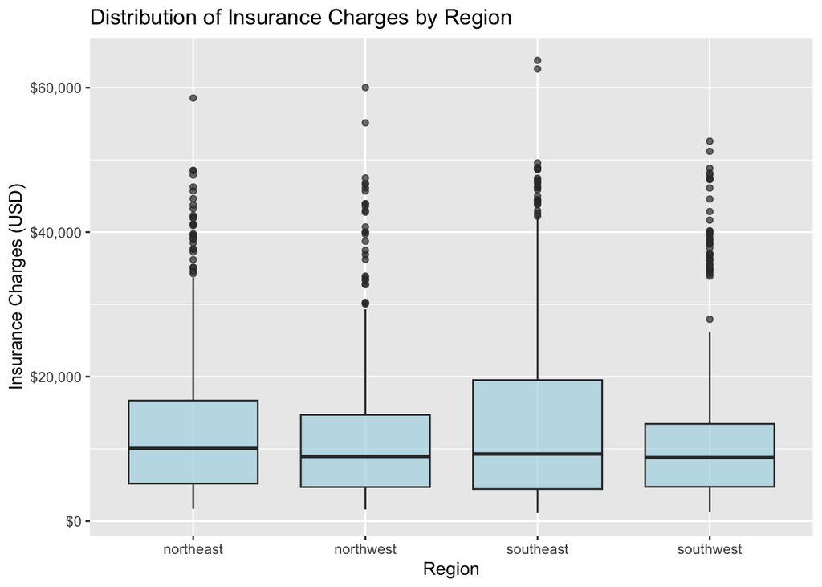

## 3.2 Scatter Plot: BMI vs. Charges, Colored by Smoking Status

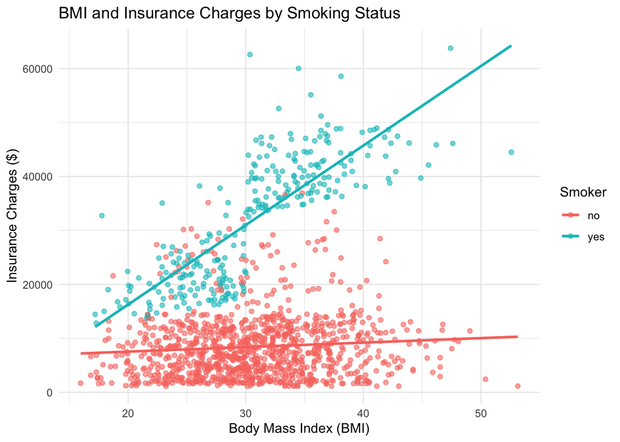

## Scatter plot:

The scatter plot shows that insurance charges increase with higher BMI, particularly among smokers. Smokers consistently have higher medical costs than non-smokers across all BMI levels, with the steep upward slope indicating that obesity amplifies expenses for this group. In contrast, non-smokers show relatively stable charges regardless of BMI. Overall, smoking and high BMI appear to interact to substantially raise healthcare costs.